# Cadillac Deville Prices

### Overview

**Context**

In this study, I will be looking at the relationship between the selling price of Cadillac Devilles and the mileage on those Cadillacs.

**The Study**

To perform this study, I will use a sample of 30 Cadillac Devilles in three different Trim styles.

```r
CarPrices <- read.csv("../Data/CarPrices.csv", header=TRUE, stringsAsFactors = FALSE)
DevillePrice <- subset(CarPrices, Model == "Deville")
pander(table(DevillePrice$Trim))
```

| DHS Sedan 4D | DTS Sedan 4D | Sedan 4D |
| --- | --- | --- |
| 10 | 10 | 10 |

**The Data**

```r
datatable(DevillePrice, extensions = "Responsive",options=list(lengthMenu = c(5,30)))
```

|  | Price | Mileage | Make | Model | Trim | Type | Cylinder | Liter | Doors | Cruise | Sound | Leather |
| --- | --- | --- | --- | --- | --- | --- | --- | --- | --- | --- | --- | --- |
| 101 | 39801.55135 | 14095 | Cadillac | Deville | DHS Sedan 4D | Sedan | 8 | 4.6 | 4 | 1 | 0 | 1 |
| 102 | 40335.73731 | 14743 | Cadillac | Deville | DHS Sedan 4D | Sedan | 8 | 4.6 | 4 | 1 | 0 | 1 |
| 103 | 39307.00916 | 16041 | Cadillac | Deville | DHS Sedan 4D | Sedan | 8 | 4.6 | 4 | 1 | 0 | 1 |
| 104 | 38600.23956 | 17138 | Cadillac | Deville | DHS Sedan 4D | Sedan | 8 | 4.6 | 4 | 1 | 0 | 1 |
| 105 | 38445.89717 | 18661 | Cadillac | Deville | DHS Sedan 4D | Sedan | 8 | 4.6 | 4 | 1 | 0 | 1 |
| 106 | 36077.79612 | 21966 | Cadillac | Deville | DHS Sedan 4D | Sedan | 8 | 4.6 | 4 | 1 | 0 | 1 |
| 107 | 35866.58271 | 24415 | Cadillac | Deville | DHS Sedan 4D | Sedan | 8 | 4.6 | 4 | 1 | 1 | 1 |
| 108 | 35338.65369 | 25163 | Cadillac | Deville | DHS Sedan 4D | Sedan | 8 | 4.6 | 4 | 1 | 0 | 1 |
| 109 | 36154.30355 | 25339 | Cadillac | Deville | DHS Sedan 4D | Sedan | 8 | 4.6 | 4 | 1 | 1 | 1 |
| 110 | 34685.66298 | 25421 | Cadillac | Deville | DHS Sedan 4D | Sedan | 8 | 4.6 | 4 | 1 | 0 | 1 |

[output cut: 20 more lines]

### Analysis

#### Analysis

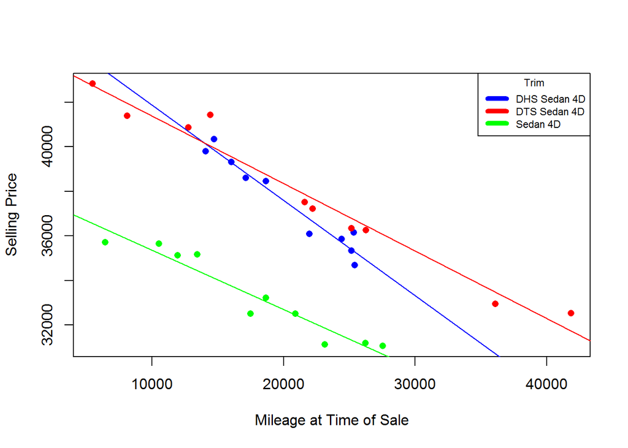

```r
lmcd <- lm(Price ~ Mileage + Trim + Mileage:Trim, data=DevillePrice)


palette(c("blue","red","green"))
plot(Price~Mileage,data=DevillePrice,
     col=as.factor(DevillePrice$Trim),pch=16,
     xlab="Mileage at Time of Sale", ylab="Selling Price")
b<-lmcd$coefficients
abline(b[1], b[2], col="blue")
abline(b[1]+ b[3],b[2]+ b[5], col="red")
abline(b[1]+ b[4],b[2]+ b[6], col="green")
legend("topright",c("DHS Sedan 4D","DTS Sedan 4D","Sedan 4D"), lty=1, lwd=5, col=palette(), cex=0.7, title="Trim")
```

It appears that each Trim model has different predicted new price and different depreciation.

I will test to see if there is evidence to suggest that the the trim model have different linear models.

#### Inference

```r
pander(lmcd)
```

Fitting linear model: Price ~ Mileage + Trim + Mileage:Trim

|  | Estimate | Std. Error | t value | Pr(>\|t\|) |
| --- | --- | --- | --- | --- |
| **(Intercept)** | 46151 | 885.2 | 52.13 | 3.272e-26 |
| **Mileage** | -0.4281 | 0.04261 | -10.05 | 4.49e-10 |
| **TrimDTS Sedan 4D** | -1731 | 975.6 | -1.774 | 0.08875 |
| **TrimSedan 4D** | -8132 | 1035 | -7.86 | 4.308e-08 |
| **Mileage:TrimDTS Sedan 4D** | 0.1246 | 0.04589 | 2.716 | 0.01205 |
| **Mileage:TrimSedan 4D** | 0.1621 | 0.05122 | 3.164 | 0.004185 |

The test of multiple linear regression confirms what the scatterplot shows; these three models are not all the same.

This is the Price:Mileage Model for all three Trims Styles:

$\quad Y_{i} = \text{Sales Price}$ $\quad X_{i1} = \text{Mileage}$ $\quad X_{i2} = \left\{\begin{array}{ll} 1, & \text{if Trim} = \text{DTS Sedan 4D} \\ 0, & \text{if Trim}\neq \text{DTS Sedan 4D} \end{array}\right.$ $\quad X_{i3} = \left\{\begin{array}{ll} 1, & \text{if Trim} = \text{Sedan 4D} \\ 0, & \text{if Trim}\neq \text{Sedan 4D} \end{array}\right.$

$$\underbrace{Y_i}_{Price}=\beta_0+\beta_1\underbrace{X_{i1}}_{Mileage}+\beta_2{X_{i2}}+\beta_3{X_{i3}}+\beta_4{X_{i1}X_{i2}}+\beta_5{X_{i1}X_{i3}}+\epsilon_i$$

$\hat{ Y }_{ i }=$ 4.615138510^{4} + -0.4281188 ${ X }_{ i1 }+$ -1730.7876218 ${ X }_{ i2 }+$ -8132.2317868 ${ X }_{ i3 }+$ 0.1246406 ${ X }_{ i1 }{ X }_{ i2 }+$ 0.1620959 ${ X }_{ i1 }{ X }_{ i3 }$

### Assumptions

1. **Linear Relation**: Seems Appropriate.
2. **Normal Errors**: Slightly Skewed
3. **Constant Variance**: Seems Appropriate
4. **Fixed X**: Mileage is accureate.
5. **Independent Errors**: the error terms are independent.

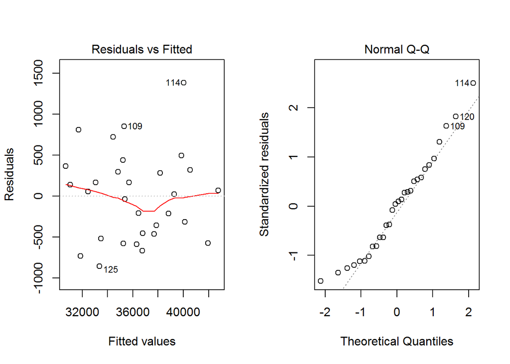

```r
par(mfrow=c(1,2))
plot(lmcd, which=1:2)
```

```r
par(mfrow = c(1,1))
```

### Interpretation

I am convinced that the different Trim Styles of the Cadillac Deville have different Linear Depreciation Models. The DHS Model appears to have the highest new selling price and the fastest depreciation.